# DIALLO ALPHA OUMAR / TP SVM

### Extension du SVM non-linéaire aux données CTG

```python
# Chargement du nouveau jeu de données
df_ctg = pd.read_csv("./CTGSimple.csv", sep="\t", header=1)
```

```python
Y_ctg = df_ctg["NSP"].values
variables_ctg = ["LB", "AC.1", "FM.1", "UC.1", "DL.1", "DS.1", "DP.1", "ASTV",
                 "MSTV", "ALTV", "MLTV", "Width", "Min", "Max", "Nmax", "Nzeros",
                 "Mode", "Mean", "Median", "Variance", "Tendency"]
X_ctg = df_ctg[variables_ctg].values
```

```python
uniqLabels_ctg, counts_ctg = np.unique(Y_ctg, return_counts=True)
for i, lab in enumerate(uniqLabels_ctg):
    print("Classe {} contient {} points".format(lab, counts_ctg[i]))
```

```
Classe 1 contient 1655 points
Classe 2 contient 295 points
Classe 3 contient 176 points
```

```python
classe = 3
Y_ctg[np.in1d(Y_ctg, classe)] = 2
```

```python
# Séparation des données en ensembles d'entraînement et de validation
X_ctg_train, X_ctg_val, Y_ctg_train, Y_ctg_val = train_test_split(X_ctg, Y_ctg, test_size=0.2, random_state=42)
```

```python
# Normalisation des ensembles d'entraînement et de validation
scaler_ctg = StandardScaler()
X_ctg_train_scaled = scaler_ctg.fit_transform(X_ctg_train)
X_ctg_val_scaled = scaler_ctg.transform(X_ctg_val)
```

```python
pca = PCA(n_components=2)
X_ctg_train_pca = pca.fit_transform(X_ctg_train_scaled)
X_ctg_val_pca = pca.transform(X_ctg_val_scaled)
```

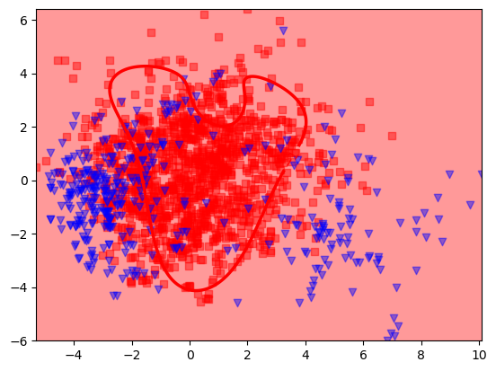

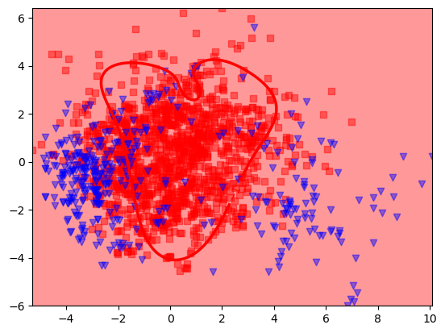

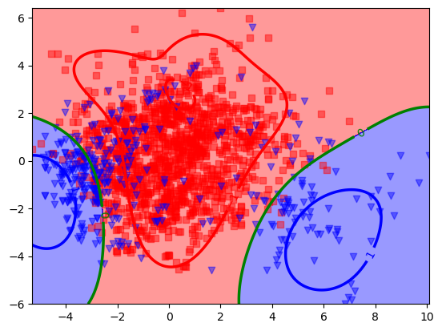

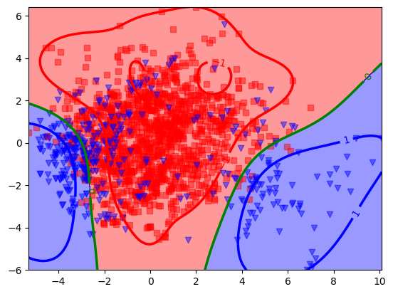

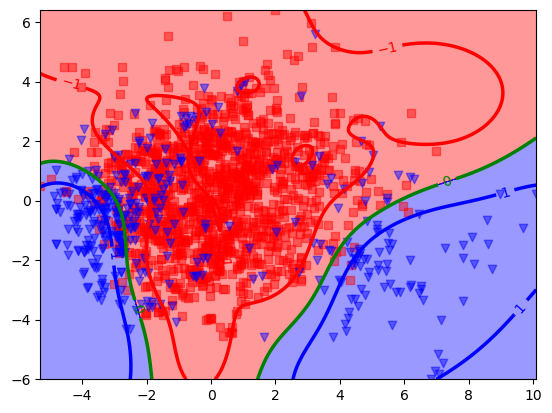

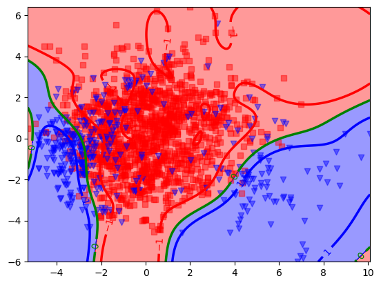

```python
# Boucle sur les différentes valeurs de C
for paramC in vectC:
    clf_svm_ctg_pca = SVC(kernel='rbf', C=paramC)
    clf_svm_ctg_pca.fit(X_ctg_train_pca, Y_ctg_train)

    plt.figure()
    plot_decision_margin_2d(X_ctg_train_pca, Y_ctg_train, clf_svm_ctg_pca, 0.02, titre=f"C = {paramC}")
    plt.show()
```

### RECHERCHE DES MEILLEURS HYPERPARAMETRES

```python
param_grid_rbf = {'C': np.logspace(-3, 2, 6),
                  'gamma': np.logspace(-2, 2, 6)}

grid_search_rbf = GridSearchCV(SVC(kernel='rbf'), param_grid_rbf, cv=5, scoring='accuracy')
grid_search_rbf.fit(X_ctg_train_scaled, Y_ctg_train)

print("Meilleurs hyper-paramètres (RBF): ", grid_search_rbf.best_params_)
```

```
Meilleurs hyper-paramètres (RBF):  {'C': 100.0, 'gamma': 0.06309573444801933}
```

### Performances

```python
clf_svm_ctg_rbf = SVC(kernel='rbf', C=grid_search_rbf.best_params_['C'], gamma=grid_search_rbf.best_params_['gamma'])
clf_svm_ctg_rbf.fit(X_ctg_train_scaled, Y_ctg_train)

# Évaluation sur l'ensemble d'entraînement
err_train_rbf = 1 - accuracy_score(Y_ctg_train, clf_svm_ctg_rbf.predict(X_ctg_train_scaled))
print("Erreur d'entraînement (RBF): {:.2f}%".format(100 * err_train_rbf))

# Évaluation sur l'ensemble de validation
err_val_rbf = 1 - accuracy_score(Y_ctg_val, clf_svm_ctg_rbf.predict(X_ctg_val_scaled))
print("Erreur de validation (RBF): {:.2f}%".format(100 * err_val_rbf))
```

```
Erreur d'entraînement (RBF): 0.29%
Erreur de validation (RBF): 5.87%
```

## Matrice de confusion

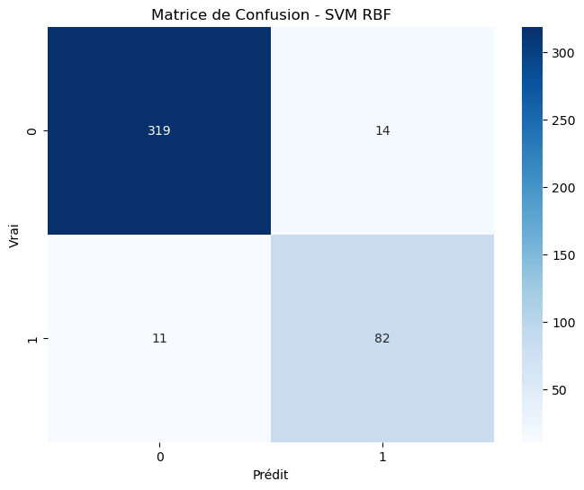

```python
# Prédictions sur l'ensemble de validation
Y_pred_val = clf_svm_ctg_rbf.predict(X_ctg_val_scaled)

# Calcul de la matrice de confusion
conf_matrix = confusion_matrix(Y_ctg_val, Y_pred_val)

# Affichage de la matrice de confusion
plt.figure(figsize=(8, 6))
sns.heatmap(conf_matrix, annot=True, fmt="d", cmap="Blues")
plt.title("Matrice de Confusion - SVM RBF")
plt.xlabel("Prédit")
plt.ylabel("Vrai")
plt.show()
```

## Pubs ou pas pubs

### Chargement , séparation et normalisations des données

```python
# Chargement des données
train_data = pd.read_csv("commercial_train.csv")
test_data = pd.read_csv("commercial_test.csv")

# Séparation des caractéristiques et des labels
X_train = train_data.iloc[:, :-1].values
Y_train = train_data.iloc[:, -1].values
X_test = test_data.iloc[:, :-1].values
Y_test = test_data.iloc[:, -1].values

# Normalisation des données
scaler = StandardScaler()
X_train_scaled = scaler.fit_transform(X_train)
X_test_scaled = scaler.transform(X_test)
```

### Utilisation du modèle de regression avec pénalité L2

### Recherche de paramètre optimal

```python
import warnings
from sklearn.exceptions import ConvergenceWarning
from sklearn.linear_model import LogisticRegression
from sklearn.model_selection import GridSearchCV
from sklearn.metrics import accuracy_score

# Ignorer les avertissements de convergence
warnings.simplefilter('ignore', ConvergenceWarning)

# Recherche en grille pour la régression logistique avec un nombre d'itérations plus élevé
param_grid_logreg = {'C': np.logspace(-4, 4, 20)}
logreg = LogisticRegression(penalty='l2', max_iter=1000)

grid_search_logreg = GridSearchCV(logreg, param_grid_logreg, cv=5, scoring='accuracy')
grid_search_logreg.fit(X_train_scaled, Y_train)

print("Meilleur paramètre pour la régression logistique : ", grid_search_logreg.best_params_)
```

```
Meilleur paramètre pour la régression logistique :  {'C': 10000.0}
```

### Entrainement du modèl

```python
# Entraînement du modèle avec le meilleur C et un nombre d'itérations élevé
best_logreg = LogisticRegression(penalty='l2', C=grid_search_logreg.best_params_['C'], max_iter=1000)
best_logreg.fit(X_train_scaled, Y_train)
```

```
LogisticRegression(C=10000.0, max_iter=1000)
```

### Prédiction sur l'ensemble Test

```python
# Évaluation du modèle sur l'ensemble de test
Y_pred_logreg = best_logreg.predict(X_test_scaled)
accuracy_logreg = accuracy_score(Y_test, Y_pred_logreg)
print("Précision de la régression logistique sur l'ensemble de test : {:.2f}%".format(100 * accuracy_logreg))
```

```
Précision de la régression logistique sur l'ensemble de test : 93.83%
```

Un modèle relativement bien ajusté avec avec un accuary de 93% , donc ça veut dire qu'il se trompe que 7%

# Modele SVM à noyau Gaussien

### Recherche des hyperparamètres optimaux

```python
param_grid_svm = {
    'C': np.logspace(-3, 2, 4),
    'gamma': np.logspace(-2, 2, 4)
}

# Création du modèle SVM avec noyau RBF
svm_rbf = SVC(kernel='rbf')

# Recherche en grille avec parallélisation
grid_search_svm = GridSearchCV(svm_rbf, param_grid_svm, cv=5, scoring='accuracy', n_jobs=-1)
grid_search_svm.fit(X_train_scaled, Y_train)

# Affichage des meilleurs hyper-paramètres
print("Meilleurs hyper-paramètres pour SVM (RBF): ", grid_search_svm.best_params_)
```

```
Meilleurs hyper-paramètres pour SVM (RBF):  {'C': 2.1544346900318843, 'gamma': 0.01}
```

### Choix meilleur modèl

```python
# Entraînement du modèle SVM avec les meilleurs hyperparamètres trouvés
best_svm_rbf = SVC(kernel='rbf', C=grid_search_svm.best_params_['C'], gamma=grid_search_svm.best_params_['gamma'])
best_svm_rbf.fit(X_train_scaled, Y_train)
```

```
SVC(C=2.1544346900318843, gamma=0.01)
```

### Prédiction sur l'ensemble test

```python
# Évaluation du modèle sur l'ensemble de test
Y_pred_svm = best_svm_rbf.predict(X_test_scaled)
accuracy_svm = accuracy_score(Y_test, Y_pred_svm)
print("Précision du SVM (RBF) sur l'ensemble de test : {:.2f}%".format(100 * accuracy_svm))
```

```
Précision du SVM (RBF) sur l'ensemble de test : 95.60%
```

# Comparaison sur des deux modèles

Nous avons observé que le modèle SVM avec un noyau RBF (gaussien) a atteint une précision de 95% sur l'ensemble de TEST, tandis que le modèle de régression logistique avec pénalisation L2 a obtenu une précision de 93%. Ces résultats indiquent que, bien que les deux modèles présentent des performances globalement élevées, le modèle SVM avec noyau RBF se révèle légèrement plus performant pour cet ensemble de données spécifique. Cela souligne l'importance de choisir et de régler correctement le modèle en fonction des caractéristiques propres à l'ensemble de données traité. Mais notons que le Grid search pour le SVM peut être très long.

### Confusion Matrice

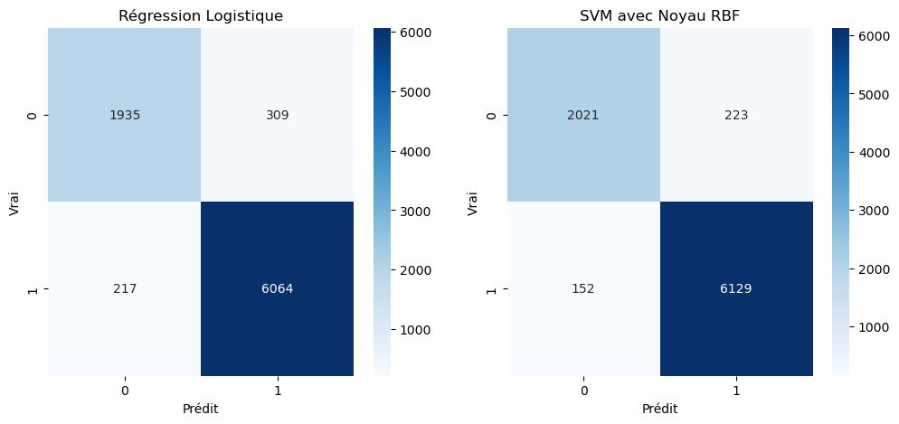

```python
# Calcul des matrices de confusion
conf_matrix_logreg = confusion_matrix(Y_test, Y_pred_logreg)
conf_matrix_svm = confusion_matrix(Y_test, Y_pred_svm)

# Création des graphiques
fig, ax = plt.subplots(1, 2, figsize=(12, 5))

# Matrice de confusion pour la régression logistique
sns.heatmap(conf_matrix_logreg, annot=True, fmt="d", cmap="Blues", ax=ax[0])
ax[0].set_title("Régression Logistique")
ax[0].set_xlabel("Prédit")
ax[0].set_ylabel("Vrai")

# Matrice de confusion pour le SVM
sns.heatmap(conf_matrix_svm, annot=True, fmt="d", cmap="Blues", ax=ax[1])
ax[1].set_title("SVM avec Noyau RBF")
ax[1].set_xlabel("Prédit")
ax[1].set_ylabel("Vrai")

plt.show()
```

Comme observé dans les résultats d'accuracy, la matrice de confusion du modèle SVM avec noyau RBF révèle une meilleure reconnaissance des vrais positifs (VP) et des vrais négatifs (VN) par rapport à la régression logistique pénalisée. Cette tendance se manifeste par un nombre plus élevé de classifications correctes dans ces deux catégories pour le SVM. En outre, le modèle SVM commet moins d'erreurs de classification, à savoir les faux positifs (FP) et les faux négatifs (FN), que la régression logistique pénalisée.

Cela suggère que le SVM avec noyau RBF est non seulement plus précis en général, mais aussi plus fiable dans la distinction entre les différentes classes. Ces performances supérieures peuvent être attribuées à la capacité du noyau RBF à modéliser des frontières de décision complexes et non linéaires, ce qui est particulièrement avantageux dans des scénarios où les relations entre les caractéristiques et les classes ne sont pas clairement définies par des frontières linéaires.